# Mid Term - Animal Rights Index

hg420@scarletmail.rutgers.edu

2024-04-01

```r
## Libraries

library(readr)
library(MVA)
library(HSAUR2)
library(SciViews)
```

```r
library(scatterplot3d)
library(car)
library(lattice)
library(GGally)
library(ggplot2)
library(ggridges)
library(ggvis)
library(ggthemes)
library(cowplot)
library(gapminder)
library(gganimate)
library(dplyr)
library(tidyverse)
library(grid)
library(gridExtra)
library(RColorBrewer)
library(Hotelling)
library(stats)
library(biotools)
library(factoextra)
library(FactoMineR)
library(ggfortify)
library(psych)
library(corrplot)
library(devtools)
library(cluster)
library(magrittr)
library(NbClust)
library(MASS)
library(gvlma)
library(leaps)
library(relaimpo)
library(readr)
animal <- read.csv("C:/Users/user/Desktop/MVA Mid term/Animal_Rights.csv", row.names=1)
str(animal)
```

```
## 'data.frame':    67 obs. of  10 variables:
##  $ Recognition.of.Animal.Sentience                        : int  1 1 1 1 1 1 1 1 1 1 ...
##  $ Recognition.of.Animal.Suffering                        : int  1 1 1 1 1 1 1 1 1 1 ...
##  $ Any.Laws.Against.Animal.Cruelty                        : int  1 1 1 1 1 1 1 1 1 1 ...
##  $ Support.for.the.Universal.Declaration.of.Animal.Welfare: int  2 2 2 2 2 0 1 2 2 1 ...
##  $ Fur.Farming.Ban                                        : int  1 1 1 1 1 1 2 1 2 2 ...
##  $ Meat.Consumption.per.Capita.in.Kilograms               : num  80.1 79.9 87.2 82.8 65.8 ...
##  $ Percentage.of.Protected.Areas                          : num  40.9 28.7 28.4 22.2 23.3 ...
##  $ Kgs.of.Pesticide...Hectare.of.Cropland                 : num  2.8 3.2 3.3 1.7 6.7 1.8 0.6 7.9 0.9 4.7 ...
##  $ Environmental.Performance.Index.Score                  : num  82.3 81.3 79.6 71 73.3 63.1 78.7 75.3 57 81.5 ...
##  $ Total.Score                                            : num  520 506 502 499 489 ...
```

```r
attach(animal)
head(animal)
```

```
##                Recognition.of.Animal.Sentience Recognition.of.Animal.Suffering
## Luxembourg                                   1                               1
## United Kingdom                               1                               1
## Austria                                      1                               1
## Czechia                                      1                               1
## Belgium                                      1                               1
## Croatia                                      1                               1
##                Any.Laws.Against.Animal.Cruelty
## Luxembourg                                   1
## United Kingdom                               1
## Austria                                      1
## Czechia                                      1
## Belgium                                      1
## Croatia                                      1
##                Support.for.the.Universal.Declaration.of.Animal.Welfare
## Luxembourg                                                           2
## United Kingdom                                                       2
## Austria                                                              2
## Czechia                                                              2
## Belgium                                                              2
## Croatia                                                              0
##                Fur.Farming.Ban Meat.Consumption.per.Capita.in.Kilograms
## Luxembourg                   1                                    80.07
## United Kingdom               1                                    79.89
## Austria                      1                                    87.22
## Czechia                      1                                    82.78
## Belgium                      1                                    65.77
## Croatia                      1                                    75.29
##                Percentage.of.Protected.Areas
## Luxembourg                             40.87
## United Kingdom                         28.68
## Austria                                28.40
## Czechia                                22.16
## Belgium                                23.29
## Croatia                                38.25
##                Kgs.of.Pesticide...Hectare.of.Cropland
## Luxembourg                                        2.8
## United Kingdom                                    3.2
## Austria                                           3.3
## Czechia                                           1.7
## Belgium                                           6.7
## Croatia                                           1.8
##                Environmental.Performance.Index.Score Total.Score
## Luxembourg                                      82.3      519.68
## United Kingdom                                  81.3      506.36
## Austria                                         79.6      501.73
## Czechia                                         71.0      498.66
## Belgium                                         73.3      488.86
## Croatia                                         63.1      486.36
```

```r
dim(animal)
```

```
## [1] 67 10
```

```r
str(animal)
```

```
## 'data.frame':    67 obs. of  10 variables:
##  $ Recognition.of.Animal.Sentience                        : int  1 1 1 1 1 1 1 1 1 1 ...
##  $ Recognition.of.Animal.Suffering                        : int  1 1 1 1 1 1 1 1 1 1 ...
##  $ Any.Laws.Against.Animal.Cruelty                        : int  1 1 1 1 1 1 1 1 1 1 ...
##  $ Support.for.the.Universal.Declaration.of.Animal.Welfare: int  2 2 2 2 2 0 1 2 2 1 ...
##  $ Fur.Farming.Ban                                        : int  1 1 1 1 1 1 2 1 2 2 ...
##  $ Meat.Consumption.per.Capita.in.Kilograms               : num  80.1 79.9 87.2 82.8 65.8 ...
##  $ Percentage.of.Protected.Areas                          : num  40.9 28.7 28.4 22.2 23.3 ...
##  $ Kgs.of.Pesticide...Hectare.of.Cropland                 : num  2.8 3.2 3.3 1.7 6.7 1.8 0.6 7.9 0.9 4.7 ...
##  $ Environmental.Performance.Index.Score                  : num  82.3 81.3 79.6 71 73.3 63.1 78.7 75.3 57 81.5 ...
##  $ Total.Score                                            : num  520 506 502 499 489 ...
```

```r
names(animal)
```

```
##  [1] "Recognition.of.Animal.Sentience"
##  [2] "Recognition.of.Animal.Suffering"
##  [3] "Any.Laws.Against.Animal.Cruelty"
##  [4] "Support.for.the.Universal.Declaration.of.Animal.Welfare"
##  [5] "Fur.Farming.Ban"
##  [6] "Meat.Consumption.per.Capita.in.Kilograms"
##  [7] "Percentage.of.Protected.Areas"
##  [8] "Kgs.of.Pesticide...Hectare.of.Cropland"
##  [9] "Environmental.Performance.Index.Score"
## [10] "Total.Score"
```

```r
#1. Describe the data and its values briefly
summary(animal)
```

```
##  Recognition.of.Animal.Sentience Recognition.of.Animal.Suffering
##  Min.   :0.0000                  Min.   :0.0000
##  1st Qu.:0.0000                  1st Qu.:1.0000
##  Median :1.0000                  Median :1.0000
##  Mean   :0.7164                  Mean   :0.8955
##  3rd Qu.:1.0000                  3rd Qu.:1.0000
##  Max.   :2.0000                  Max.   :2.0000
##  Any.Laws.Against.Animal.Cruelty
##  Min.   :0.0000
##  1st Qu.:1.0000
##  Median :1.0000
##  Mean   :0.9701
##  3rd Qu.:1.0000
##  Max.   :2.0000
##  Support.for.the.Universal.Declaration.of.Animal.Welfare Fur.Farming.Ban
##  Min.   :0.0000                                          Min.   :0.0000
##  1st Qu.:0.0000                                          1st Qu.:0.0000
##  Median :1.0000                                          Median :1.0000
##  Mean   :0.9701                                          Mean   :0.8955
##  3rd Qu.:2.0000                                          3rd Qu.:2.0000
##  Max.   :2.0000                                          Max.   :2.0000
##  Meat.Consumption.per.Capita.in.Kilograms Percentage.of.Protected.Areas
##  Min.   :  3.78                           Min.   : 0.22
##  1st Qu.: 37.42                           1st Qu.:10.70
##  Median : 65.77                           Median :18.47
##  Mean   : 61.48                           Mean   :19.69
##  3rd Qu.: 81.36                           3rd Qu.:27.64
##  Max.   :124.10                           Max.   :54.14
##  Kgs.of.Pesticide...Hectare.of.Cropland Environmental.Performance.Index.Score
##  Min.   : 0.00006                       Min.   :25.10
##  1st Qu.: 0.80000                       1st Qu.:44.00
##  Median : 2.00000                       Median :57.00
##  Mean   : 3.19900                       Mean   :57.27
##  3rd Qu.: 4.80000                       3rd Qu.:71.15
##  Max.   :13.10000                       Max.   :82.50
##   Total.Score
##  Min.   : 12.46
##  1st Qu.:252.23
##  Median :359.53
##  Mean   :342.78
##  3rd Qu.:451.29
##  Max.   :519.68
```

```r
#Ans: The dataset contains 67 rows which symbolize numerous nations, and a number of columns that gauge different facets of environmental and animal rights. The majority of variables that range from 0 to 2 that deal with animal sentience, suffering, anti-cruelty laws, support for animal welfare declarations, and fur-farming prohibitions receive positive scores. The range of meat intake per person, which reflects a variety of diets, is 3.78 to 124.10 kilos. Variations in pesticide usage and conservation efforts are evident in the environmental metrics, which range from 0.00006 to 13.1 kg per hectare and the percentage of protected areas from 0.22% to 54.14%, respectively. Together with a cumulative assessment of animal rights statuses, the Environmental Performance Index Score (25.10 to 82.50) and a Total Score (12.46 to 519.68) capture the overall effectiveness of environmental policies.
```

```r
#2 Analysing the data
#Visualize the countries across all the dimensions in one chart so you can easily see similar countries. (10 points)
str(animal)
```

```
## 'data.frame':    67 obs. of  10 variables:
##  $ Recognition.of.Animal.Sentience                        : int  1 1 1 1 1 1 1 1 1 1 ...
##  $ Recognition.of.Animal.Suffering                        : int  1 1 1 1 1 1 1 1 1 1 ...
##  $ Any.Laws.Against.Animal.Cruelty                        : int  1 1 1 1 1 1 1 1 1 1 ...
##  $ Support.for.the.Universal.Declaration.of.Animal.Welfare: int  2 2 2 2 2 0 1 2 2 1 ...
##  $ Fur.Farming.Ban                                        : int  1 1 1 1 1 1 2 1 2 2 ...
##  $ Meat.Consumption.per.Capita.in.Kilograms               : num  80.1 79.9 87.2 82.8 65.8 ...
##  $ Percentage.of.Protected.Areas                          : num  40.9 28.7 28.4 22.2 23.3 ...
##  $ Kgs.of.Pesticide...Hectare.of.Cropland                 : num  2.8 3.2 3.3 1.7 6.7 1.8 0.6 7.9 0.9 4.7 ...
##  $ Environmental.Performance.Index.Score                  : num  82.3 81.3 79.6 71 73.3 63.1 78.7 75.3 57 81.5 ...
##  $ Total.Score                                            : num  520 506 502 499 489 ...
```

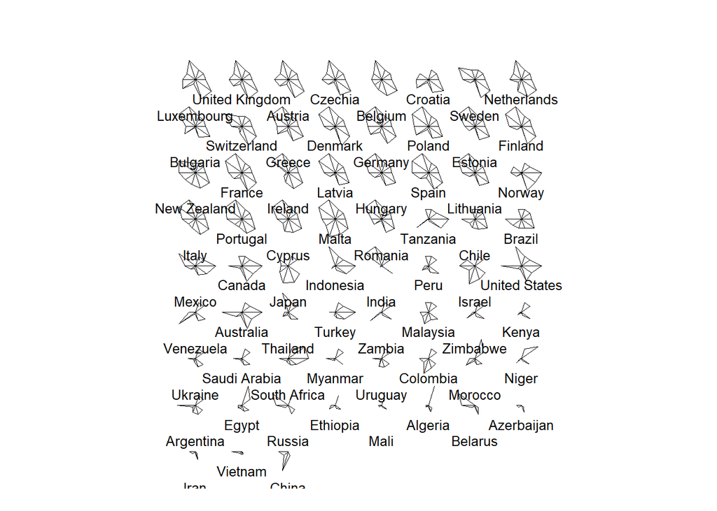

```r
animal1 <- animal[-11] #remove the column from the datastructure
stars(animal1)
```

```r
str(animal1)
```

```
## 'data.frame':    67 obs. of  10 variables:
##  $ Recognition.of.Animal.Sentience                        : int  1 1 1 1 1 1 1 1 1 1 ...
##  $ Recognition.of.Animal.Suffering                        : int  1 1 1 1 1 1 1 1 1 1 ...
##  $ Any.Laws.Against.Animal.Cruelty                        : int  1 1 1 1 1 1 1 1 1 1 ...
##  $ Support.for.the.Universal.Declaration.of.Animal.Welfare: int  2 2 2 2 2 0 1 2 2 1 ...
##  $ Fur.Farming.Ban                                        : int  1 1 1 1 1 1 2 1 2 2 ...
##  $ Meat.Consumption.per.Capita.in.Kilograms               : num  80.1 79.9 87.2 82.8 65.8 ...
##  $ Percentage.of.Protected.Areas                          : num  40.9 28.7 28.4 22.2 23.3 ...
##  $ Kgs.of.Pesticide...Hectare.of.Cropland                 : num  2.8 3.2 3.3 1.7 6.7 1.8 0.6 7.9 0.9 4.7 ...
##  $ Environmental.Performance.Index.Score                  : num  82.3 81.3 79.6 71 73.3 63.1 78.7 75.3 57 81.5 ...
##  $ Total.Score                                            : num  520 506 502 499 489 ...
```

```r
summary(animal1)
```

```
##  Recognition.of.Animal.Sentience Recognition.of.Animal.Suffering
##  Min.   :0.0000                  Min.   :0.0000
##  1st Qu.:0.0000                  1st Qu.:1.0000
##  Median :1.0000                  Median :1.0000
##  Mean   :0.7164                  Mean   :0.8955
##  3rd Qu.:1.0000                  3rd Qu.:1.0000
##  Max.   :2.0000                  Max.   :2.0000
##  Any.Laws.Against.Animal.Cruelty
##  Min.   :0.0000
##  1st Qu.:1.0000
##  Median :1.0000
##  Mean   :0.9701
##  3rd Qu.:1.0000
##  Max.   :2.0000
##  Support.for.the.Universal.Declaration.of.Animal.Welfare Fur.Farming.Ban
##  Min.   :0.0000                                          Min.   :0.0000
##  1st Qu.:0.0000                                          1st Qu.:0.0000
##  Median :1.0000                                          Median :1.0000
##  Mean   :0.9701                                          Mean   :0.8955
##  3rd Qu.:2.0000                                          3rd Qu.:2.0000
##  Max.   :2.0000                                          Max.   :2.0000
##  Meat.Consumption.per.Capita.in.Kilograms Percentage.of.Protected.Areas
##  Min.   :  3.78                           Min.   : 0.22
##  1st Qu.: 37.42                           1st Qu.:10.70
##  Median : 65.77                           Median :18.47
##  Mean   : 61.48                           Mean   :19.69
##  3rd Qu.: 81.36                           3rd Qu.:27.64
##  Max.   :124.10                           Max.   :54.14
##  Kgs.of.Pesticide...Hectare.of.Cropland Environmental.Performance.Index.Score
##  Min.   : 0.00006                       Min.   :25.10
##  1st Qu.: 0.80000                       1st Qu.:44.00
##  Median : 2.00000                       Median :57.00
##  Mean   : 3.19900                       Mean   :57.27
##  3rd Qu.: 4.80000                       3rd Qu.:71.15
##  Max.   :13.10000                       Max.   :82.50
##   Total.Score
##  Min.   : 12.46
##  1st Qu.:252.23
##  Median :359.53
##  Mean   :342.78
##  3rd Qu.:451.29
##  Max.   :519.68
```

```r
#Compute the distance between the countries across the different dimensions.
#3
matstd.data <- scale(animal)

# Creating a (Euclidean) distance matrix of the standardized data
dist.data <- dist(matstd.data, method="euclidean")
colnames(dist.data) <- rownames(dist.data)

dist.data
```

```
##                Luxembourg United Kingdom   Austria   Czechia   Belgium
## United Kingdom  1.1175024
## Austria         1.1857060      0.2776055
## Czechia         1.8660851      0.9740492 0.9167705
## Belgium         2.1179972      1.3476595 1.3937689 1.6131120
## Croatia         2.4776921      2.5957468 2.5936783 2.6430474 3.0026097
## Sweden          2.9073636      2.1354564 2.1496249 1.7707168 2.5429330
## Netherlands     3.1418658      2.1662596 2.1405630 2.1382930 1.2146746
## Bulgaria        2.2100430      2.1793046 2.2238502 2.0038381 2.5105270
## Switzerland     3.3182484      2.4032102 2.4353591 2.2688971 2.1165702
## Greece          1.5418573      1.5130728 1.5383659 1.7190682 1.9454691
## Denmark         2.4526881      1.6509240 1.7136792 1.4451283 2.1393042
## Germany         1.3402834      1.4821370 1.4438245 1.9800598 2.0577004
## Poland          1.7987238      2.0057952 1.9321636 2.0592221 2.5352604
## Estonia         2.5694667      1.8991289 1.9335254 1.3873248 2.1105022
## Finland         2.7231437      1.8739707 1.8889039 1.4478082 2.3187437
## New Zealand     2.5351231      2.3378907 2.2265427 2.6717064 2.1685308
## France          1.8508026      1.2120559 1.1927888 1.4292100 1.6397012
## Ireland         3.6285453      2.9414132 3.0861759 2.9466270 2.1213601
## Latvia          2.7742961      2.0611279 2.0569105 1.4335038 2.1892539
## Hungary         2.3576808      1.7126611 1.6581911 1.2596064 1.9153244
## Spain           1.9144266      1.4550630 1.3065262 1.5432851 1.9403153
## Lithuania       2.7880759      2.0192891 1.9605673 1.3588429 2.1943958
## Norway          3.5168078      2.9700712 3.0028648 2.7633802 3.2128924
## Italy           2.4797575      1.7516053 1.6948140 1.7821714 1.3122443
## Portugal        2.4546957      1.7990920 1.6674017 1.7059516 1.6262041
## Cyprus          3.0983569      2.3924668 2.3528083 2.3797276 1.4687622
## Malta           3.2811244      2.9982920 2.9492137 3.4006426 2.1752236
## Romania         2.4385891      1.9324933 1.9623778 1.5370751 2.2264884
## Tanzania        4.6397896      4.6724776 4.7493046 4.4227536 4.5782759
## Chile           3.2850330      2.6371645 2.5491845 2.3242911 2.1605676
## Brazil          3.0398715      2.7472211 2.6067754 2.6121357 2.5218945
## Mexico          4.3162088      3.7669424 3.7483475 3.3258456 3.6245294
## Canada          3.8015956      3.0238879 2.9814459 2.6297668 2.9919428
## Japan           4.2259675      3.9796349 4.0167400 4.3312953 3.2645162
## Indonesia       5.0141448      4.4964278 4.5645573 3.9515879 4.1715001
## India           5.7877878      5.2173697 5.2735970 4.6158882 4.7757990
## Peru            4.3441100      3.9573993 4.0162936 3.5864891 3.6449082
## Israel          4.7481319      4.2976136 4.2123586 4.4199807 3.5959685
## United States   3.8780834      3.2131102 3.0525067 2.8330273 3.4006821
```

[output cut: 749 more lines]

```
## Uruguay
## Colombia
## Morocco
## Niger
## Argentina
## Egypt
## Russia
## Ethiopia
## Mali
## Algeria
## Belarus
## Azerbaijan
## Iran
## Vietnam        1.3739568
## China          4.0379530 3.4925132
```

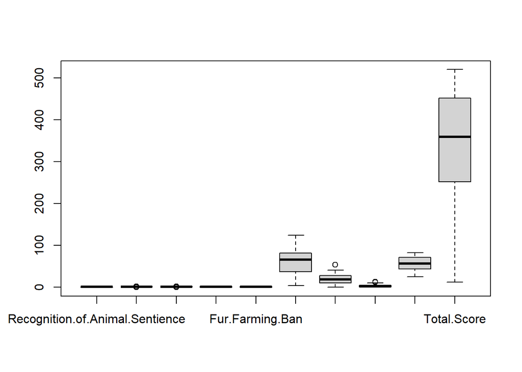

```r
boxplot(animal1)
```

```r
#Outliers seen in the boxplot
```

#computing the Euclidean distance between countries based on their standardized data across different dimensions. By scaling the “animal” dataset, it ensures that each dimension contributes equally to the distance calculation. The resulting “dist.data” matrix represents pairwise distances between countries, facilitating comparisons and clustering based on their similarity across multiple dimensions.

#Cluster Analysis # Identify Optimal Clusters #Hierarchical

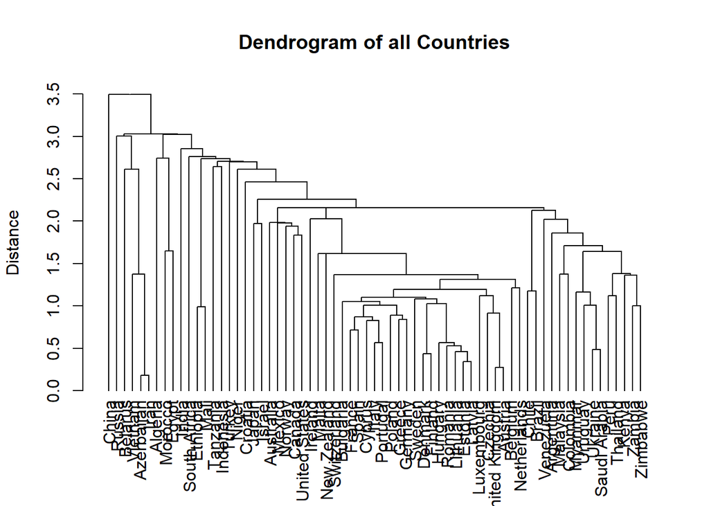

```r
# Invoking hclust command (cluster analysis by single linkage method)
clusdataset.nn <- hclust(dist.data, method = "single")

#dendogram
options(repr.plot.width=10, repr.plot.height=6)  # Adjust the plot size as needed
plot(as.dendrogram(clusdataset.nn), ylab="Distance",
     main="Dendrogram of all Countries")
```

#Performing hierarchical clustering analysis using the single linkage method on the distance matrix computed earlier (`dist.data`). It creates a dendrogram visualization of the clustering results, where countries are grouped based on their similarity in multiple dimensions. The dendrogram allows for the visualization of the hierarchical structure of the clustering process and helps identify clusters or groups of countries that are more closely related to each other.

#Non-hierarchical clustering/ K-means clustering

```r
matstd_animal <- scale(animal1)
matstd_animal
```

```
##                Recognition.of.Animal.Sentience Recognition.of.Animal.Suffering
## Luxembourg                           0.4097559                       0.2648734
## United Kingdom                       0.4097559                       0.2648734
## Austria                              0.4097559                       0.2648734
## Czechia                              0.4097559                       0.2648734
## Belgium                              0.4097559                       0.2648734
## Croatia                              0.4097559                       0.2648734
## Sweden                               0.4097559                       0.2648734
## Netherlands                          0.4097559                       0.2648734
## Bulgaria                             0.4097559                       0.2648734
## Switzerland                          0.4097559                       0.2648734
## Greece                               0.4097559                       0.2648734
## Denmark                              0.4097559                       0.2648734
## Germany                              0.4097559                       0.2648734
## Poland                               0.4097559                       0.2648734
## Estonia                              0.4097559                       0.2648734
## Finland                              0.4097559                       0.2648734
## New Zealand                          0.4097559                       0.2648734
## France                               0.4097559                       0.2648734
## Ireland                              0.4097559                       0.2648734
## Latvia                               0.4097559                       0.2648734
## Hungary                              0.4097559                       0.2648734
## Spain                                0.4097559                       0.2648734
## Lithuania                            0.4097559                       0.2648734
## Norway                               1.8546845                       0.2648734
## Italy                                0.4097559                       0.2648734
## Portugal                             0.4097559                       0.2648734
## Cyprus                               0.4097559                       0.2648734
## Malta                                0.4097559                       0.2648734
## Romania                              0.4097559                       0.2648734
## Tanzania                             1.8546845                       0.2648734
## Chile                                0.4097559                       0.2648734
## Brazil                               0.4097559                       0.2648734
## Mexico                               1.8546845                       0.2648734
## Canada                               1.8546845                       0.2648734
## Japan                               -1.0351727                       0.2648734
## Indonesia                            1.8546845                       0.2648734
## India                               -1.0351727                       0.2648734
## Peru                                -1.0351727                       0.2648734
## Israel                              -1.0351727                       0.2648734
```

[output cut: 463 more lines]

```
##                                               0.3468538
## Support.for.the.Universal.Declaration.of.Animal.Welfare
##                                               0.9369543
##                                         Fur.Farming.Ban
##                                               0.9233393
##                Meat.Consumption.per.Capita.in.Kilograms
##                                              29.0447597
##                           Percentage.of.Protected.Areas
##                                              11.0365546
##                  Kgs.of.Pesticide...Hectare.of.Cropland
##                                               3.3531531
##                   Environmental.Performance.Index.Score
##                                              16.5764194
##                                             Total.Score
##                                             127.2431572
```

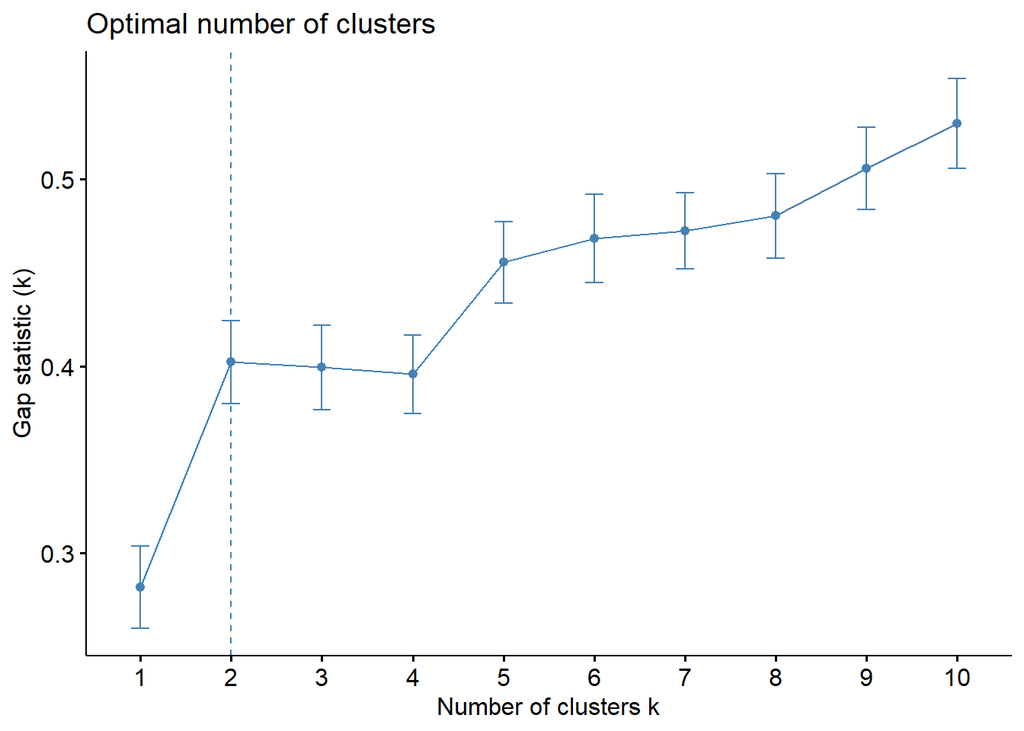

```r
fviz_nbclust(matstd_animal, kmeans, method ="gap_stat")
```